# Predictive Analysis - Problem Set 2 : Linear Regression

Swapnil Banerjee

2026-01-31

```r
rm(list = ls())
```

**1. Problem to demonstrate that the population regression line is fixed, but least square regression line varies**

Suppose the population regression line is given by Y = 2 + 3x, while the data comes from the model y = 2 + 3x + ε.

Step 1: For x in the range [5,10] graph the population regression line.

Step 2: Generate xi(i = 1, 2, .., n) from Uniform(5, 10) and εi(i = 1, 2, .., n) from N(0, 4^2). Hence, compute y1, y2, .., yn.

Step 3: On the basis of the data (xi, yi)(i = 1, 2, .., n) generated in Step 2, report the least squares regression line.

Step 4: Repeat steps 2-3 five times. Graph the 5 least squares regression lines over the population regression line obtained in Step 1. Interpret the findings.

Take n = 50. Set the seed as seed=123.

```r
set.seed(123)
x1=seq(5,10,length.out=200);x1
```

[output not shown]

```r
y1=2+3*x1
plot(x1,y1,type='l',col="red",lwd=3)

sim_results <- data.frame(
  iteration = 1:5,
  intercept = numeric(5),
  slope = numeric(5)
)

for (i in 1:5){
  x = runif(50, 5, 10)
  eps = rnorm(50, 0, 4)
  y = 2 + 3*x + eps
  mod = lm(y ~ x)
  abline(mod, col = i)
  sim_results$intercept[i] =coef(mod)[1]
  sim_results$slope[i]= coef(mod)[2]
  print(summary(mod)$coefficients) # More detailed output
}
```

```
##                Estimate Std. Error     t value     Pr(>|t|)
## (Intercept) -0.09638929  2.8260956 -0.03410688 9.729334e-01
## x            3.30539569  0.3651861  9.05126412 5.961769e-12
##             Estimate Std. Error   t value     Pr(>|t|)
## (Intercept) 2.792188  3.7483426 0.7449128 4.599563e-01
## x           2.761042  0.4898233 5.6368122 8.950156e-07
##             Estimate Std. Error   t value     Pr(>|t|)
## (Intercept) 1.392997  2.7885513 0.4995416 6.196801e-01
## x           3.073267  0.3670719 8.3723847 6.062269e-11
##             Estimate Std. Error  t value     Pr(>|t|)
## (Intercept) 2.823089  2.7354376 1.032043 3.072243e-01
## x           3.023608  0.3623615 8.344175 6.681863e-11
##             Estimate Std. Error   t value     Pr(>|t|)
## (Intercept) 2.032506  3.1772492 0.6397063 5.254052e-01
## x           3.028097  0.4091446 7.4010440 1.789935e-09
```

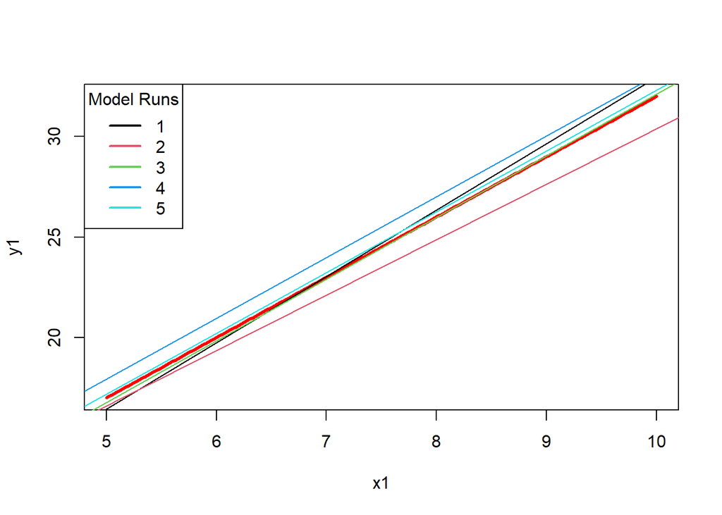

```r
legend("topleft",
       legend = paste(1:5),
       col = 1:5,
       lty = 1,
       lwd = 2,
       title = "Model Runs")
```

```r
sim_results
```

```
##   iteration   intercept    slope
## 1         1 -0.09638929 3.305396
## 2         2  2.79218839 2.761042
## 3         3  1.39299737 3.073267
## 4         4  2.82308856 3.023608
## 5         5  2.03250638 3.028097
```

Step 1: Generate xi from Uniform(5, 10) and mean center the values. Generate εi from N(0, 1). Calculate yi = 2 + 3xi + εi, i = 1,2,.., n. Take n=50 and seed=123.

Step 2: Now imagine that you only have the data on (xi, yi), i = 1, 2, .., n, without knowing the mechanism that was used to generate the data in step 1. Assuming a linear regression of the type yi = β0 + βxi + εi, and based on these data (xi, yi), i = 1, 2, .., n, obtain the least squares estimates of β0 and β.

Step 3: Take a large number of grid values of (β0, β) that also include the least squares estimates obtained from step 2. Compute the RSS for each parametric choice of (β0, β), where RSS = (y1 − β0 − βx1)^2 + (y2 − β0 − βx2)^2 + ….(yn −β0 − βxn)^2. Find out for which combination of (β0, β), RSS is minimum.

```r
n <- 50
xi <- runif(n, 5, 10)
xi_std <- xi - mean(xi)
eps <- rnorm(n, 0, 1)
y <- 2 + 3 * xi_std + eps

fit <- lm(y ~ xi_std)
beta0_hat <- coef(fit)[1]
beta_hat <- coef(fit)[2]

beta0_grid <- seq(beta0_hat - 2, beta0_hat + 2, length = 50)
beta_grid <- seq(beta_hat - 2, beta_hat + 2, length = 50)

RSS <- matrix(NA, 50, 50)

for (i in 1:50) {
  for (j in 1:50) {
    RSS[i, j] <- sum((y - beta0_grid[i] - beta_grid[j] * x)^2)
  }
}
RSS
```

```
##           [,1]     [,2]     [,3]     [,4]     [,5]      [,6]      [,7]
##  [1,] 3245.195 3696.447 4187.884 4719.508 5291.318  5903.314  6555.496
##  [2,] 3299.659 3755.988 4252.504 4789.205 5366.093  5983.167  6640.427
##  [3,] 3354.789 3816.197 4317.790 4859.569 5441.535  6063.687  6726.025
##  [4,] 3410.586 3877.071 4383.742 4930.600 5517.643  6144.873  6812.289
##  [5,] 3467.049 3938.612 4450.361 5002.297 5594.418  6226.726  6899.220
##  [6,] 3524.179 4000.819 4517.646 5074.660 5671.859  6309.245  6986.816
##  [7,] 3581.974 4063.693 4585.598 5147.689 5749.967  6392.430  7075.080
##  [8,] 3640.437 4127.233 4654.216 5221.385 5828.740  6476.282  7164.009
##  [9,] 3699.565 4191.440 4723.501 5295.748 5908.181  6560.800  7253.605
## [10,] 3759.360 4256.313 4793.451 5370.776 5988.287  6645.985  7343.868
## [11,] 3819.822 4321.852 4864.069 5446.471 6069.060  6731.835  7434.797
## [12,] 3880.949 4388.058 4935.352 5522.833 6150.500  6818.353  7526.392
## [13,] 3942.744 4454.930 5007.302 5599.861 6232.606  6905.536  7618.654
## [14,] 4005.204 4522.468 5079.919 5677.555 6315.378  6993.387  7711.582
```

[output cut: 342 more lines]

```r
which(RSS == min(RSS), arr.ind = TRUE)
```

```
##      row col
## [1,]   1   1
```

**3. Problem to demonstrate that least square estimators are unbiased**

Step 1: Generate xi(i = 1, 2, .., n) from Uniform(0, 1), εi(i = 1, 2, .., n) from N(0, 1) and hence generate y using yi = β0 + βxi + εi. (Take β0 = 2, β = 3).

Step 2: On the basis of the data (xi, yi)(i = 1, 2, .., n) generated in Step 1, obtain the least square estimates of β0 and β.

Take n = 50 and seed=123.

```r
set.seed(123)
n3 <- 50
R <- 10000

beta0_hat_vec <- array()
beta_hat_vec <- array()
eps3 <- rnorm(n3,0,1)

for(r in 1:R){
  x3 <- runif(n3,0,1)
  y3 <- 2 + 3*x3 + eps3



  fit3 <- lm(y3 ~ x3)
  beta0_hat_vec[r] <- coef(fit3)[1]
  beta_hat_vec[r] <- coef(fit3)[2]
}

predicted_beta0_hat <- sum(beta0_hat_vec)/R
predicted_beta0_hat
```

```
## [1] 2.033112
```

```r
predicted_beta_hat_vec <- sum(beta_hat_vec)/R
predicted_beta_hat_vec
```

```
## [1] 3.00193
```

**4. Comparing several simple linear regressions**

Attach “Boston” data from MASS library in R. Select median value of owner- occupied homes, as the response and per capita crime rate, nitrogen oxides concentration, proportion of blacks and percentage of lower status of the population as predictors.

1. Selecting the predictors one by one, run four separate linear regressions to the data. Present the output in a single table.
2. Which model gives the best fit?
3. Compare the coefficients of the predictors from each model and comment on the usefulness of the predictors.

```r
library(MASS)
data(Boston)

fit1 <- lm(medv ~ crim, data=Boston)
fit2 <- lm(medv ~ nox, data=Boston)
fit3 <- lm(medv ~ black, data=Boston)
fit4 <- lm(medv ~ lstat, data=Boston)

summary_table <- data.frame(
  Model = c("crim","nox","black","lstat"),
  Intercept = c(coef(fit1)[1], coef(fit2)[1], coef(fit3)[1], coef(fit4)[1]),
  Slope = c(coef(fit1)[2], coef(fit2)[2], coef(fit3)[2], coef(fit4)[2]),
  R2 = c(summary(fit1)$r.squared,
         summary(fit2)$r.squared,
         summary(fit3)$r.squared,
         summary(fit4)$r.squared)
)

print(summary_table)
```

```
##       Model Intercept        Slope        R2
## crim   crim  24.03311  -0.41519028 0.1507805
## nox     nox  41.34587 -33.91605501 0.1826030
## black black  10.55103   0.03359306 0.1111961
## lstat lstat  34.55384  -0.95004935 0.5441463
```

```r
best_model <- summary_table[which.max(summary_table$R2), ]
best_model
```

```
##       Model Intercept      Slope        R2
## lstat lstat  34.55384 -0.9500494 0.5441463
```